# Module 59

#### Contrast SVE:

Signed variance explained (SVE) provides an indication of how similar a set of fold changes are to a gene module’s weight vector. An SVE value of 0.3, for example, indicates that 30% of the variance explained by the entire module set is accounted for by the module in question. Shown here are the SVE values for this module across a compendium of fold changes (contrasts). Extreme SVE values (e.g., > 0.05) indicate that those contrasts specifically induce (orange dots) or specifically repress (blue dots) this module. Examining the experimental conditions being compared in such contrasts (see tables below the figure) may provide insight into the gene module’s function.

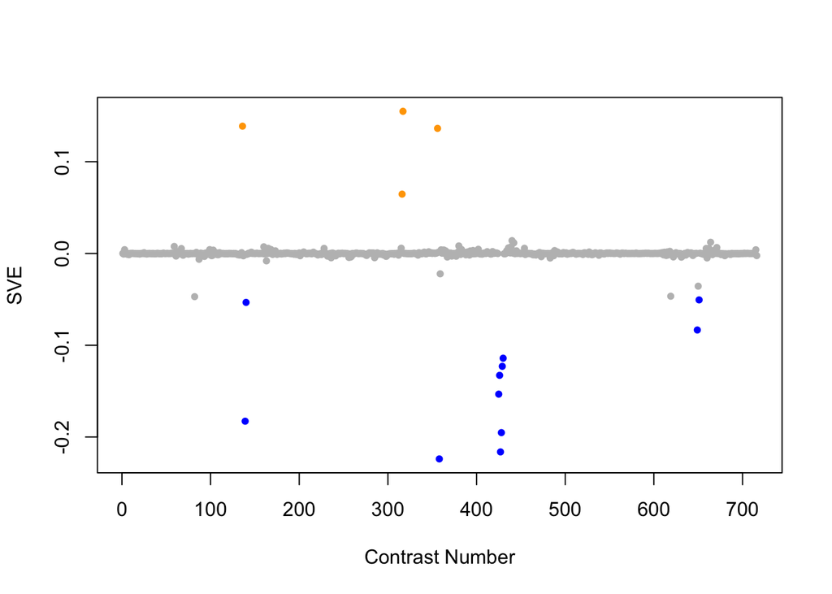

Positive SVE Contrasts:

|  | Contrast.Num | SVE | GEO.GSE | Cond.1 | Cond.2 | Mutation |
| --- | --- | --- | --- | --- | --- | --- |
| GSE39145.s1t1.vs.s0t1 | 317 | 0.15 | GSE39145 | ercc-1_I | wild-type_N2_I | ercc-1 |
| GSE51691.s2t1.vs.s1t1 | 136 | 0.14 | GSE51691 | day8 hermaphrodite +males rep 1 | day8 hermaphrodite -males rep 1 |  |
| GSE38196.s1t1.vs.s0t1 | 356 | 0.14 | GSE38196 | atfs-1(tm4525)-control, biological rep1 | wild-type-control, biological rep1 | afts-1 |
| GSE39252.s1t1.vs.s0t1 | 316 | 0.06 | GSE39252 | xpa-1_rep1 | N2_rep1 | xpa-1 |
| GSE27677B.s1t2.vs.s1t1 | 440 | 0.01 | GSE27677 | N2, Fast 3 h, rep 1 | N2, Fed 0 h, rep 1 |  |

Negative SVE Contrasts:

|  | Contrast.Num | SVE | GEO.GSE | Cond.1 | Cond.2 | Mutation |
| --- | --- | --- | --- | --- | --- | --- |
| GSE38196.s1t2.vs.s1t1 | 358 | -0.22 | GSE38196 | atfs-1(tm4525)-treated, biological rep1 | atfs-1(tm4525)-control, biological rep1 | spg-7(RNAi) |
| GSE27677A.s1t2.vs.s0t2 | 427 | -0.22 | GSE27677 | kgb-1, Fast , rep 1 | N2, Fast , rep 1 | kgb-1 |
| GSE27677A.s3t1.vs.s0t1 | 428 | -0.20 | GSE27677 | daf-16, Fed , rep 1 | N2, Fed , rep 1 | daf-16 |
| GSE51691.s3t1.vs.s2t1 | 139 | -0.18 | GSE51691 | day8 hermaphrodite utx-1 RNAi -males rep 1 | day8 hermaphrodite +males rep 1 |  |
| GSE27677A.s3t2.vs.s0t2 | 425 | -0.15 | GSE27677 | daf-16, Fast , rep 1 | N2, Fast , rep 1 | daf-16 |
| GSE27677A.s2t2.vs.s0t2 | 426 | -0.13 | GSE27677 | jun-1, Fast , rep 1 | N2, Fast , rep 1 | 40694 |
| GSE27677A.s2t1.vs.s0t1 | 429 | -0.12 | GSE27677 | jun-1, Fed , rep 1 | N2, Fed , rep 1 | 40694 |
| GSE27677A.s1t1.vs.s0t1 | 430 | -0.11 | GSE27677 | kgb-1, Fed , rep 1 | N2, Fed , rep 1 | kgb-1 |
| GSE16405.s2t1.vs.s1t1 | 649 | -0.08 | GSE16405 | nth-1_1 | N2_1 | nth-1 |
| GSE51691.s4t1.vs.s2t1 | 140 | -0.05 | GSE51691 | day8 hermaphrodite utx-1 RNAi +males rep 1 | day8 hermaphrodite +males rep 1 | utx-1(RNAi) |
| GSE16405.s4t1.vs.s1t1 | 651 | -0.05 | GSE16405 | xpa-1_1 | N2_1 | xpa-1 |

$~$

#### Contrast SVE, Up-Regulated Genes Only:

Calculating SVE for up-regulated and down-regulated genes separately may be more informative in many cases than projecting the up- and down- gene sets together. This is due to the fact that the weight distribution of many modules is highly skewed, indicating that only one of the hemi-modules may be biologically meaningful (i.e., a set of genes are strongly correlated by only a few genes (or none) are strongly anti-correlated to that set.)

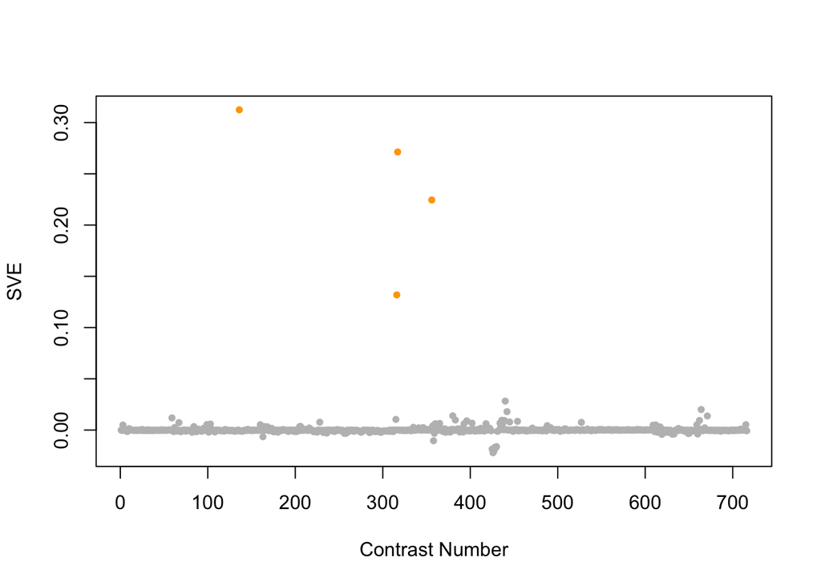

Positive SVE Contrasts:

|  | Contrast.Num | SVE | GEO.GSE | Cond.1 | Cond.2 | Mutation |
| --- | --- | --- | --- | --- | --- | --- |
| GSE51691.s2t1.vs.s1t1 | 136 | 0.31 | GSE51691 | day8 hermaphrodite +males rep 1 | day8 hermaphrodite -males rep 1 |  |
| GSE39145.s1t1.vs.s0t1 | 317 | 0.27 | GSE39145 | ercc-1_I | wild-type_N2_I | ercc-1 |
| GSE38196.s1t1.vs.s0t1 | 356 | 0.22 | GSE38196 | atfs-1(tm4525)-control, biological rep1 | wild-type-control, biological rep1 | afts-1 |
| GSE39252.s1t1.vs.s0t1 | 316 | 0.13 | GSE39252 | xpa-1_rep1 | N2_rep1 | xpa-1 |
| GSE27677B.s1t2.vs.s1t1 | 440 | 0.03 | GSE27677 | N2, Fast 3 h, rep 1 | N2, Fed 0 h, rep 1 |  |

Negative SVE Contrasts:

|  | Contrast.Num | SVE | GEO.GSE | Cond.1 | Cond.2 | Mutation |
| --- | --- | --- | --- | --- | --- | --- |
| GSE27677A.s2t2.vs.s0t2 | 426 | -0.02 | GSE27677 | jun-1, Fast , rep 1 | N2, Fast , rep 1 | 40694 |
| GSE27677A.s1t2.vs.s0t2 | 427 | -0.02 | GSE27677 | kgb-1, Fast , rep 1 | N2, Fast , rep 1 | kgb-1 |
| GSE27677A.s3t2.vs.s0t2 | 425 | -0.02 | GSE27677 | daf-16, Fast , rep 1 | N2, Fast , rep 1 | daf-16 |
| GSE27677A.s2t1.vs.s0t1 | 429 | -0.02 | GSE27677 | jun-1, Fed , rep 1 | N2, Fed , rep 1 | 40694 |
| GSE27677A.s3t1.vs.s0t1 | 428 | -0.02 | GSE27677 | daf-16, Fed , rep 1 | N2, Fed , rep 1 | daf-16 |

$~$

#### Contrast SVE, Down-Regulated Genes Only:

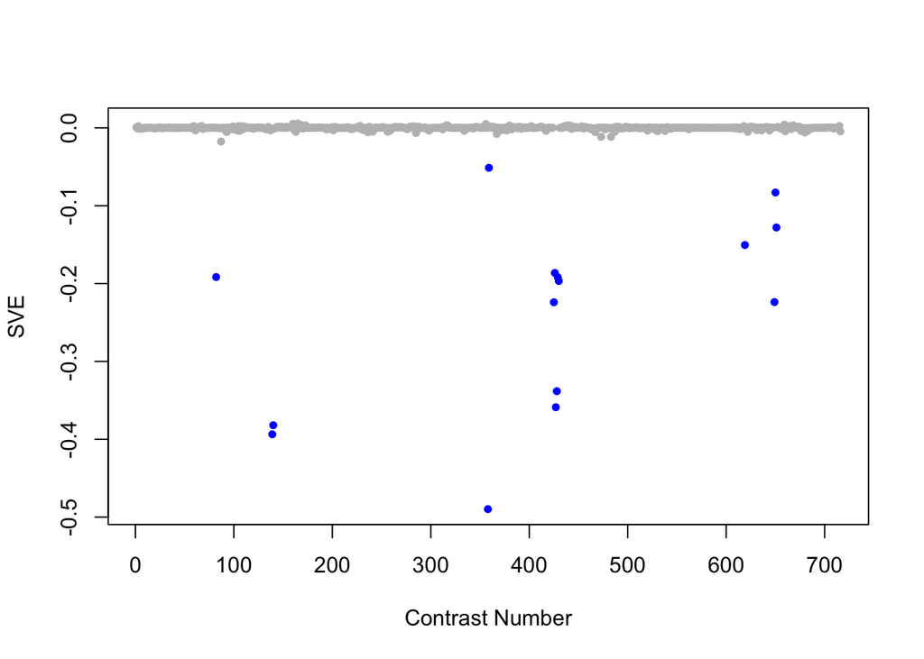

Positive SVE Contrasts:

|  | Contrast.Num | SVE | GEO.GSE | Cond.1 | Cond.2 | Mutation |
| --- | --- | --- | --- | --- | --- | --- |
| GSE47778.s1t2.vs.s4t2 | 165 | 0.01 | GSE47778 | N2; starvation; replicate 1 | daf-2;daf-16; starvation; replicate 1 | daf-2;daf-16 |
| GSE47778.s2t2.vs.s3t2 | 160 | 0.01 | GSE47778 | daf-2; starvation; replicate 1 | daf-16; starvation; replicate 1 | daf-2 vs. daf-16 |
| GSE38196.s1t1.vs.s0t1 | 356 | 0.00 | GSE38196 | atfs-1(tm4525)-control, biological rep1 | wild-type-control, biological rep1 | afts-1 |
| GSE47778.s1t2.vs.s3t2 | 162 | 0.00 | GSE47778 | N2; starvation; replicate 1 | daf-16; starvation; replicate 1 | daf-16 |
| GSE15762.s1t1.vs.s0t1 | 659 | 0.00 | GSE15762 | hlh-30(tm1978)-1 | N2-1 | hlh-30 |

Negative SVE Contrasts:

|  | Contrast.Num | SVE | GEO.GSE | Cond.1 | Cond.2 | Mutation |
| --- | --- | --- | --- | --- | --- | --- |
| GSE38196.s1t2.vs.s1t1 | 358 | -0.49 | GSE38196 | atfs-1(tm4525)-treated, biological rep1 | atfs-1(tm4525)-control, biological rep1 | spg-7(RNAi) |
| GSE51691.s3t1.vs.s2t1 | 139 | -0.39 | GSE51691 | day8 hermaphrodite utx-1 RNAi -males rep 1 | day8 hermaphrodite +males rep 1 |  |
| GSE51691.s4t1.vs.s2t1 | 140 | -0.38 | GSE51691 | day8 hermaphrodite utx-1 RNAi +males rep 1 | day8 hermaphrodite +males rep 1 | utx-1(RNAi) |
| GSE27677A.s1t2.vs.s0t2 | 427 | -0.36 | GSE27677 | kgb-1, Fast , rep 1 | N2, Fast , rep 1 | kgb-1 |
| GSE27677A.s3t1.vs.s0t1 | 428 | -0.34 | GSE27677 | daf-16, Fed , rep 1 | N2, Fed , rep 1 | daf-16 |
| GSE27677A.s3t2.vs.s0t2 | 425 | -0.22 | GSE27677 | daf-16, Fast , rep 1 | N2, Fast , rep 1 | daf-16 |
| GSE16405.s2t1.vs.s1t1 | 649 | -0.22 | GSE16405 | nth-1_1 | N2_1 | nth-1 |
| GSE27677A.s1t1.vs.s0t1 | 430 | -0.20 | GSE27677 | kgb-1, Fed , rep 1 | N2, Fed , rep 1 | kgb-1 |
| GSE27677A.s2t1.vs.s0t1 | 429 | -0.19 | GSE27677 | jun-1, Fed , rep 1 | N2, Fed , rep 1 | 40694 |
| GSE7354.s2t1.vs.s1t1 | 82 | -0.19 | GSE7354 | whole animal, nucleus accumbens: Extract1_le1 | whole animal, nucleus accumbens: Extract-Control_le1 |  |
| GSE27677A.s2t2.vs.s0t2 | 426 | -0.19 | GSE27677 | jun-1, Fast , rep 1 | N2, Fast , rep 1 | 40694 |
| GSE21467.s1t1.vs.s0t1 | 619 | -0.15 | GSE21467 | ung-1, biological rep1 | wild type N2, biological rep1 | ung-1 |
| GSE16405.s4t1.vs.s1t1 | 651 | -0.13 | GSE16405 | xpa-1_1 | N2_1 | xpa-1 |
| GSE16405.s3t1.vs.s1t1 | 650 | -0.08 | GSE16405 | nth-1;xpa-1_1 | N2_1 | nth-1;xpa-1 |
| GSE38196.s0t2.vs.s0t1 | 359 | -0.05 | GSE38196 | wild-type-treated, biological rep1 | wild-type-control, biological rep1 | spg-7(RNAi) |

$~$

$~$

#### GO Term Enrichment:

This analysis tests each hemi-module for enrichment of specific GO terms. Only gene-level annotations (e.g., as would be found on the gene’s page in Wormbase) are tested - the hierarchical structure of the GO ontology is not taken into account.

*Note: At least the top two most enriched terms from each GO domain (BP/MF/CC) are shown, even when not statistically significant.*

##### Enriched GO terms: Hemi-module A

| ID | GO.Term | GO Domain | Raw p-value | Adj p-value |
| --- | --- | --- | --- | --- |
| [GO_0006508](http://amigo.geneontology.org/amigo/term/GO:0006508) | proteolysis | BP | 5.36e-05 | 1.95e-01 |
| [GO_0018996](http://amigo.geneontology.org/amigo/term/GO:0018996) | molting cycle, collagen and cuticulin-based cuticle | BP | 7.11e-03 | 9.97e-01 |
| [GO_0030246](http://amigo.geneontology.org/amigo/term/GO:0030246) | carbohydrate binding | MF | 2.21e-49 | 4.52e-46 |
| [GO_0016936](http://amigo.geneontology.org/amigo/term/GO:0016936) | galactoside binding | MF | 2.37e-07 | 2.42e-04 |
| [GO_0016020](http://amigo.geneontology.org/amigo/term/GO:0016020) | membrane | CC | 2.25e-09 | 2.08e-06 |
| [GO_0016021](http://amigo.geneontology.org/amigo/term/GO:0016021) | integral component of membrane | CC | 2.53e-08 | 1.17e-05 |
| [GO_0005634](http://amigo.geneontology.org/amigo/term/GO:0005634) | nucleus | CC | 1.61e-05 | 4.99e-03 |
| [GO_0005615](http://amigo.geneontology.org/amigo/term/GO:0005615) | extracellular space | CC | 4.01e-05 | 9.31e-03 |
| [GO_0005737](http://amigo.geneontology.org/amigo/term/GO:0005737) | cytoplasm | CC | 1.63e-04 | 3.02e-02 |

##### Enriched GO terms: Hemi-module B

| ID | GO.Term | GO Domain | Raw p-value | Adj p-value |
| --- | --- | --- | --- | --- |
| [GO_0032259](http://amigo.geneontology.org/amigo/term/GO:0032259) | methylation | BP | 2.30e-02 | 1.00e+00 |
| [GO_0055114](http://amigo.geneontology.org/amigo/term/GO:0055114) | oxidation-reduction process | BP | 1.22e-01 | 1.00e+00 |
| [GO_0016705](http://amigo.geneontology.org/amigo/term/GO:0016705) | oxidoreductase activity, acting on paired donors, with incorporation or reduction of molecular oxygen | MF | 1.98e-02 | 1.00e+00 |
| [GO_0004497](http://amigo.geneontology.org/amigo/term/GO:0004497) | monooxygenase activity | MF | 2.20e-02 | 1.00e+00 |
| [GO_0005634](http://amigo.geneontology.org/amigo/term/GO:0005634) | nucleus | CC | 5.72e-01 | 1.00e+00 |
| [GO_0016020](http://amigo.geneontology.org/amigo/term/GO:0016020) | membrane | CC | 6.11e-01 | 1.00e+00 |

$~$

$~$

#### Tissue Enrichment:

This analysis tests each hemi-module for enrichment of genes associated with anatomy terms. Negative enrichment scores indicate fewer hemi-module genes than expected by random chance were associated with the anatomy term in question.

##### Enriched tissues: Hemi-module A

| ID | Anatomy.Term | Definition | Raw p-value | Adj p-value |
| --- | --- | --- | --- | --- |
| [WBbt_0005337](https://wormbase.org/species/all/anatomy_term/WBbt:0005337) | vas deferens | That portion of the male reproductive tract, through which sperm are delivered to the proctodeum and then the cloaca in the tail. Thus that portion which is distal to the testis, made of a total of 30… | 5.43e-12 | 1.32e-08 |
| [WBbt_0006870](https://wormbase.org/species/all/anatomy_term/WBbt:0006870) | seminal vesicle | part of male gonad that holds mature sperm, made of a total of 12 nuclei. | 2.05e-09 | 2.49e-06 |
| [WBbt_0004052](https://wormbase.org/species/all/anatomy_term/WBbt:0004052) | R1AL | Post-embryonic cell of pedigree V5L.pppppaaa, male sensory rays, neuron, striated rootlet. | 6.39e-04 | 6.85e-02 |
| [WBbt_0004035](https://wormbase.org/species/all/anatomy_term/WBbt:0004035) | R3AR | Post-embryonic cell of pedigree V6R.papppaaa, male sensory rays, neuron, striated rootlet. | 6.80e-04 | 6.85e-02 |
| [WBbt_0004036](https://wormbase.org/species/all/anatomy_term/WBbt:0004036) | R3AL | Post-embryonic cell of pedigree V6L.papppaaa, male sensory rays, neuron, striated rootlet. | 6.80e-04 | 6.85e-02 |
| [WBbt_0003992](https://wormbase.org/species/all/anatomy_term/WBbt:0003992) | R8AR | Male sensory rays, neuron, striated rootlet | 7.67e-04 | 6.85e-02 |
| [WBbt_0003994](https://wormbase.org/species/all/anatomy_term/WBbt:0003994) | R8AL | Post-embryonic cell of pedigree TL.appaaaaa, male sensory rays, neuron, striated rootlet. | 7.67e-04 | 6.85e-02 |
| [WBbt_0004029](https://wormbase.org/species/all/anatomy_term/WBbt:0004029) | R4AR | Post-embryonic cell of pedigree V6R.pppapaaa, male sensory rays, neuron, striated rootlet. | 7.67e-04 | 6.85e-02 |
| [WBbt_0004030](https://wormbase.org/species/all/anatomy_term/WBbt:0004030) | R4AL | Post-embryonic cell of pedigree V6L.pppapaaa, male sensory rays, neuron, striated rootlet. | 7.67e-04 | 6.85e-02 |
| [WBbt_0004050](https://wormbase.org/species/all/anatomy_term/WBbt:0004050) | R1AR | Post-embryonic cell of pedigree V5R.pppppaaa, male sensory rays, neuron, striated rootlet. | 7.67e-04 | 6.85e-02 |
| [WBbt_0004002](https://wormbase.org/species/all/anatomy_term/WBbt:0004002) | R7AR | Male sensory rays, neuron, striated rootlet | 8.13e-04 | 6.85e-02 |
| [WBbt_0004006](https://wormbase.org/species/all/anatomy_term/WBbt:0004006) | R7AL | Post-embryonic cell of pedigree TL.apappaaa, male sensory rays, neuron, striated rootlet. | 8.13e-04 | 6.85e-02 |
| [WBbt_0004041](https://wormbase.org/species/all/anatomy_term/WBbt:0004041) | R2AR | Post-embryonic cell of pedigree V6R.papapaaa, male sensory rays, neuron, striated rootlet. | 8.13e-04 | 6.85e-02 |
| [WBbt_0004042](https://wormbase.org/species/all/anatomy_term/WBbt:0004042) | R2AL | Post-embryonic cell of pedigree V6L.papapaaa, male sensory rays, neuron, striated rootlet. | 8.13e-04 | 6.85e-02 |
| [WBbt_0004016](https://wormbase.org/species/all/anatomy_term/WBbt:0004016) | R6AR | Post-embryonic cell of pedigree V6R.pppppaaa, male sensory rays, neuron, striated rootlet. | 8.61e-04 | 6.85e-02 |
| [WBbt_0004018](https://wormbase.org/species/all/anatomy_term/WBbt:0004018) | R6AL | Post-embryonic cell of pedigree V6L.pppppaaa, male sensory rays, neuron, striated rootlet. | 8.61e-04 | 6.85e-02 |
| [WBbt_0004023](https://wormbase.org/species/all/anatomy_term/WBbt:0004023) | R5AR | Post-embryonic cell of pedigree V6R.ppppaaaa, male sensory rays, neuron, striated rootlet. | 8.61e-04 | 6.85e-02 |
| [WBbt_0004024](https://wormbase.org/species/all/anatomy_term/WBbt:0004024) | R5AL | Post-embryonic cell of pedigree V6L.ppppaaaa, male sensory rays, neuron, striated rootlet. | 8.61e-04 | 6.85e-02 |
| [WBbt_0004033](https://wormbase.org/species/all/anatomy_term/WBbt:0004033) | R3BR | Post-embryonic cell of pedigree V6R.papppapa, male sensory rays, neuron, darkly staining tip, open to outside. | 8.61e-04 | 6.85e-02 |
| [WBbt_0004034](https://wormbase.org/species/all/anatomy_term/WBbt:0004034) | R3BL | Post-embryonic cell of pedigree V6L.papppapa, male sensory rays, neuron, darkly staining tip, open to outside. | 8.61e-04 | 6.85e-02 |
| [WBbt_0003970](https://wormbase.org/species/all/anatomy_term/WBbt:0003970) | R9AR | Male sensory rays, neuron, striated rootlet | 9.11e-04 | 6.85e-02 |
| [WBbt_0003971](https://wormbase.org/species/all/anatomy_term/WBbt:0003971) | R9AL | Male sensory rays, neuron, striated rootlet | 9.11e-04 | 6.85e-02 |
| [WBbt_0004012](https://wormbase.org/species/all/anatomy_term/WBbt:0004012) | R6BR | Post-embryonic cell of pedigree V6R.pppppapa, male sensory rays, neuron, not darkly staining nor open to outside. | 9.11e-04 | 6.85e-02 |
| [WBbt_0004014](https://wormbase.org/species/all/anatomy_term/WBbt:0004014) | R6BL | Post-embryonic cell of pedigree V6L.pppppapa, male sensory rays, neuron, not darkly staining nor open to outside. | 9.11e-04 | 6.85e-02 |
| [WBbt_0004027](https://wormbase.org/species/all/anatomy_term/WBbt:0004027) | R4BR | Post-embryonic cell of pedigree V6R.pppapapa, male sensory rays, neuron, darkly staining tip, open to outside. | 9.11e-04 | 6.85e-02 |
| [WBbt_0004028](https://wormbase.org/species/all/anatomy_term/WBbt:0004028) | R4BL | Post-embryonic cell of pedigree V6L.pppapapa, male sensory rays, neuron, darkly staining tip, open to outside. | 9.11e-04 | 6.85e-02 |
| [WBbt_0004039](https://wormbase.org/species/all/anatomy_term/WBbt:0004039) | R2BR | Post-embryonic cell of pedigree V6R.papapapa, male sensory rays, neuron, darkly staining tip, open to outside. | 9.11e-04 | 6.85e-02 |
| [WBbt_0004040](https://wormbase.org/species/all/anatomy_term/WBbt:0004040) | R2BL | Post-embryonic cell of pedigree V6L.papapapa, male sensory rays, neuron, darkly staining tip, open to outside. | 9.11e-04 | 6.85e-02 |
| [WBbt_0004046](https://wormbase.org/species/all/anatomy_term/WBbt:0004046) | R1BR | Post-embryonic cell of pedigree V5R.pppppapa, male sensory rays, neuron, darkly staining tip, open to outside. | 9.11e-04 | 6.85e-02 |
| [WBbt_0004048](https://wormbase.org/species/all/anatomy_term/WBbt:0004048) | R1BL | Post-embryonic cell of pedigree V5L.pppppapa, male sensory rays, neuron, darkly staining tip, open to outside. | 9.11e-04 | 6.85e-02 |
| [WBbt_0004000](https://wormbase.org/species/all/anatomy_term/WBbt:0004000) | R7BR | Male sensory rays, neuron, darkly staining tip, open to outside | 9.62e-04 | 6.85e-02 |
| [WBbt_0004001](https://wormbase.org/species/all/anatomy_term/WBbt:0004001) | R7BL | Post-embryonic cell of pedigree TL.apappapa, male sensory rays, neuron, darkly staining tip, open to outside. | 9.62e-04 | 6.85e-02 |
| [WBbt_0003988](https://wormbase.org/species/all/anatomy_term/WBbt:0003988) | R8BR | Male sensory rays, neuron, darkly staining tip, open to outside | 1.01e-03 | 6.85e-02 |
| [WBbt_0003990](https://wormbase.org/species/all/anatomy_term/WBbt:0003990) | R8BL | Post-embryonic cell of pedigree TL.appaaapa, male sensory rays, neuron, darkly staining tip, open to outside. | 1.01e-03 | 6.85e-02 |
| [WBbt_0003966](https://wormbase.org/species/all/anatomy_term/WBbt:0003966) | R9BR | Male sensory rays, neuron, darkly staining tip, open to outside | 1.07e-03 | 6.85e-02 |
| [WBbt_0003968](https://wormbase.org/species/all/anatomy_term/WBbt:0003968) | R9BL | Post-embryonic cell of pedigree TL.appapapa, male sensory rays, neuron, darkly staining tip, open to outside. | 1.07e-03 | 6.85e-02 |
| [WBbt_0004021](https://wormbase.org/species/all/anatomy_term/WBbt:0004021) | R5BR | Post-embryonic cell of pedigree V6R.ppppaapa, male sensory rays, neuron, darkly staining tip, open to outside. | 1.07e-03 | 6.85e-02 |
| [WBbt_0004022](https://wormbase.org/species/all/anatomy_term/WBbt:0004022) | R5BL | Post-embryonic cell of pedigree V6L.ppppaapa, male sensory rays, neuron, darkly staining tip, open to outside. | 1.07e-03 | 6.85e-02 |

##### Enriched tissues: Hemi-module B

No significant annotations.

$~$

$~$

#### HOMER promoter motif enrichment:

This analysis tests each hemi-module for enrichment of 108 known *C. elegans* transcription factor binding site motifs (see [108 CE motifs](https://katiepod.github.io//all.worm.motifs.html)) using the HOMER (Hypergeometric Optimization of Motif EnRichment) software (see [PMID:20513432](https://pubmed.ncbi.nlm.nih.gov/20513432)). HOMER was run using default parameters on sequences 1 kb upstream of the transcription start site.

##### Motif enrichment: Hemi-module A

Total target sequences = 175  
Total background sequences = 39567  
* - possible false positive

Rank

Motif

P-value

log P-pvalue

% of Targets

% of Background

STD(Bg STD)

Best Match/Details

Motif File

1

[figure not shown]

1e-20

-4.756e+01

61.71%

27.25%

253.8bp (331.2bp)

POL012.1_TATA-Box/Jaspar(0.859)  
[More Information](https://katiepod.github.io/HomerResults/m59_a_hemi_genes.txt.out.1kb/homerResults/motif1.info.html) | [Similar Motifs Found](https://katiepod.github.io/HomerResults/m59_a_hemi_genes.txt.out.1kb/homerResults/motif1.similar.html)

[motif file (matrix)](https://katiepod.github.io/HomerResults/m59_a_hemi_genes.txt.out.1kb/homerResults/motif1.motif)

2

[figure not shown]

1e-19

-4.441e+01

10.86%

0.46%

44.2bp (359.6bp)

CES-1(Homeobox)/cElegans-L1-CES1-ChIP-Seq(modEncode)/Homer(0.803)  
[More Information](https://katiepod.github.io/HomerResults/m59_a_hemi_genes.txt.out.1kb/homerResults/motif2.info.html) | [Similar Motifs Found](https://katiepod.github.io/HomerResults/m59_a_hemi_genes.txt.out.1kb/homerResults/motif2.similar.html)

[motif file (matrix)](https://katiepod.github.io/HomerResults/m59_a_hemi_genes.txt.out.1kb/homerResults/motif2.motif)

3

[figure not shown]

1e-12

-2.981e+01

11.43%

1.22%

209.6bp (326.1bp)

POL010.1_DCE_S_III/Jaspar(0.645)  
[More Information](https://katiepod.github.io/HomerResults/m59_a_hemi_genes.txt.out.1kb/homerResults/motif3.info.html) | [Similar Motifs Found](https://katiepod.github.io/HomerResults/m59_a_hemi_genes.txt.out.1kb/homerResults/motif3.similar.html)

[motif file (matrix)](https://katiepod.github.io/HomerResults/m59_a_hemi_genes.txt.out.1kb/homerResults/motif3.motif)

4

[figure not shown]

1e-12

-2.845e+01

7.43%

0.38%

319.1bp (354.2bp)

EGL-5(Homeobox)/cElegans-L3-EGL5-ChIP-Seq(modEncode)/Homer(0.578)  
[More Information](https://katiepod.github.io/HomerResults/m59_a_hemi_genes.txt.out.1kb/homerResults/motif4.info.html) | [Similar Motifs Found](https://katiepod.github.io/HomerResults/m59_a_hemi_genes.txt.out.1kb/homerResults/motif4.similar.html)

[motif file (matrix)](https://katiepod.github.io/HomerResults/m59_a_hemi_genes.txt.out.1kb/homerResults/motif4.motif)

5 *

[figure not shown]

1e-10

-2.371e+01

8.57%

0.84%

278.1bp (334.0bp)

pha-4/MA0546.1/Jaspar(0.538)  
[More Information](https://katiepod.github.io/HomerResults/m59_a_hemi_genes.txt.out.1kb/homerResults/motif5.info.html) | [Similar Motifs Found](https://katiepod.github.io/HomerResults/m59_a_hemi_genes.txt.out.1kb/homerResults/motif5.similar.html)

[motif file (matrix)](https://katiepod.github.io/HomerResults/m59_a_hemi_genes.txt.out.1kb/homerResults/motif5.motif)

6 *

[figure not shown]

1e-9

-2.287e+01

8.00%

0.74%

306.5bp (302.8bp)

lin-54/MA1450.1/Jaspar(0.612)  
[More Information](https://katiepod.github.io/HomerResults/m59_a_hemi_genes.txt.out.1kb/homerResults/motif6.info.html) | [Similar Motifs Found](https://katiepod.github.io/HomerResults/m59_a_hemi_genes.txt.out.1kb/homerResults/motif6.similar.html)

[motif file (matrix)](https://katiepod.github.io/HomerResults/m59_a_hemi_genes.txt.out.1kb/homerResults/motif6.motif)

7 *

[figure not shown]

1e-9

-2.206e+01

5.71%

0.29%

328.3bp (307.9bp)

sma-4/MA0925.1/Jaspar(0.488)  
[More Information](https://katiepod.github.io/HomerResults/m59_a_hemi_genes.txt.out.1kb/homerResults/motif7.info.html) | [Similar Motifs Found](https://katiepod.github.io/HomerResults/m59_a_hemi_genes.txt.out.1kb/homerResults/motif7.similar.html)

[motif file (matrix)](https://katiepod.github.io/HomerResults/m59_a_hemi_genes.txt.out.1kb/homerResults/motif7.motif)

8 *

[figure not shown]

1e-9

-2.158e+01

6.86%

0.54%

321.2bp (340.5bp)

unc-30/MA1443.1/Jaspar(0.583)  
[More Information](https://katiepod.github.io/HomerResults/m59_a_hemi_genes.txt.out.1kb/homerResults/motif8.info.html) | [Similar Motifs Found](https://katiepod.github.io/HomerResults/m59_a_hemi_genes.txt.out.1kb/homerResults/motif8.similar.html)

[motif file (matrix)](https://katiepod.github.io/HomerResults/m59_a_hemi_genes.txt.out.1kb/homerResults/motif8.motif)

9 *

[figure not shown]

1e-9

-2.142e+01

8.00%

0.84%

276.2bp (328.1bp)

ceh-48/MA0921.1/Jaspar(0.666)  
[More Information](https://katiepod.github.io/HomerResults/m59_a_hemi_genes.txt.out.1kb/homerResults/motif9.info.html) | [Similar Motifs Found](https://katiepod.github.io/HomerResults/m59_a_hemi_genes.txt.out.1kb/homerResults/motif9.similar.html)

[motif file (matrix)](https://katiepod.github.io/HomerResults/m59_a_hemi_genes.txt.out.1kb/homerResults/motif9.motif)

10 *

[figure not shown]

1e-9

-2.130e+01

10.29%

1.57%

307.9bp (342.7bp)

fkh-9/MA1440.1/Jaspar(0.583)  
[More Information](https://katiepod.github.io/HomerResults/m59_a_hemi_genes.txt.out.1kb/homerResults/motif10.info.html) | [Similar Motifs Found](https://katiepod.github.io/HomerResults/m59_a_hemi_genes.txt.out.1kb/homerResults/motif10.similar.html)

[motif file (matrix)](https://katiepod.github.io/HomerResults/m59_a_hemi_genes.txt.out.1kb/homerResults/motif10.motif)

11 *

[figure not shown]

1e-9

-2.125e+01

9.14%

1.19%

267.7bp (332.9bp)

POL010.1_DCE_S_III/Jaspar(0.574)  
[More Information](https://katiepod.github.io/HomerResults/m59_a_hemi_genes.txt.out.1kb/homerResults/motif11.info.html) | [Similar Motifs Found](https://katiepod.github.io/HomerResults/m59_a_hemi_genes.txt.out.1kb/homerResults/motif11.similar.html)

[motif file (matrix)](https://katiepod.github.io/HomerResults/m59_a_hemi_genes.txt.out.1kb/homerResults/motif11.motif)

12 *

[figure not shown]

1e-9

-2.077e+01

4.00%

0.10%

279.1bp (240.5bp)

MF0001.1_ETS_class/Jaspar(0.604)  
[More Information](https://katiepod.github.io/HomerResults/m59_a_hemi_genes.txt.out.1kb/homerResults/motif12.info.html) | [Similar Motifs Found](https://katiepod.github.io/HomerResults/m59_a_hemi_genes.txt.out.1kb/homerResults/motif12.similar.html)

[motif file (matrix)](https://katiepod.github.io/HomerResults/m59_a_hemi_genes.txt.out.1kb/homerResults/motif12.motif)

13 *

[figure not shown]

1e-8

-2.005e+01

2.86%

0.02%

181.4bp (235.5bp)

ceh-10::ttx-3/MA0263.1/Jaspar(0.511)  
[More Information](https://katiepod.github.io/HomerResults/m59_a_hemi_genes.txt.out.1kb/homerResults/motif13.info.html) | [Similar Motifs Found](https://katiepod.github.io/HomerResults/m59_a_hemi_genes.txt.out.1kb/homerResults/motif13.similar.html)

[motif file (matrix)](https://katiepod.github.io/HomerResults/m59_a_hemi_genes.txt.out.1kb/homerResults/motif13.motif)

14 *

[figure not shown]

1e-8

-1.982e+01

9.14%

1.32%

255.1bp (321.8bp)

fkh-2/MA0920.1/Jaspar(0.552)  
[More Information](https://katiepod.github.io/HomerResults/m59_a_hemi_genes.txt.out.1kb/homerResults/motif14.info.html) | [Similar Motifs Found](https://katiepod.github.io/HomerResults/m59_a_hemi_genes.txt.out.1kb/homerResults/motif14.similar.html)

[motif file (matrix)](https://katiepod.github.io/HomerResults/m59_a_hemi_genes.txt.out.1kb/homerResults/motif14.motif)

15 *

[figure not shown]

1e-8

-1.951e+01

9.14%

1.35%

303.0bp (315.0bp)

MF0003.1_REL_class/Jaspar(0.515)  
[More Information](https://katiepod.github.io/HomerResults/m59_a_hemi_genes.txt.out.1kb/homerResults/motif15.info.html) | [Similar Motifs Found](https://katiepod.github.io/HomerResults/m59_a_hemi_genes.txt.out.1kb/homerResults/motif15.similar.html)

[motif file (matrix)](https://katiepod.github.io/HomerResults/m59_a_hemi_genes.txt.out.1kb/homerResults/motif15.motif)

16 *

[figure not shown]

1e-8

-1.940e+01

6.29%

0.52%

335.7bp (346.3bp)

lin-14/MA0261.1/Jaspar(0.578)  
[More Information](https://katiepod.github.io/HomerResults/m59_a_hemi_genes.txt.out.1kb/homerResults/motif16.info.html) | [Similar Motifs Found](https://katiepod.github.io/HomerResults/m59_a_hemi_genes.txt.out.1kb/homerResults/motif16.similar.html)

[motif file (matrix)](https://katiepod.github.io/HomerResults/m59_a_hemi_genes.txt.out.1kb/homerResults/motif16.motif)

17 *

[figure not shown]

1e-8

-1.927e+01

12.57%

2.74%

335.2bp (321.8bp)

POL009.1_DCE_S_II/Jaspar(0.586)  
[More Information](https://katiepod.github.io/HomerResults/m59_a_hemi_genes.txt.out.1kb/homerResults/motif17.info.html) | [Similar Motifs Found](https://katiepod.github.io/HomerResults/m59_a_hemi_genes.txt.out.1kb/homerResults/motif17.similar.html)

[motif file (matrix)](https://katiepod.github.io/HomerResults/m59_a_hemi_genes.txt.out.1kb/homerResults/motif17.motif)

18 *

[figure not shown]

1e-8

-1.913e+01

9.14%

1.38%

339.1bp (338.0bp)

fos-1/MA1448.1/Jaspar(0.703)  
[More Information](https://katiepod.github.io/HomerResults/m59_a_hemi_genes.txt.out.1kb/homerResults/motif18.info.html) | [Similar Motifs Found](https://katiepod.github.io/HomerResults/m59_a_hemi_genes.txt.out.1kb/homerResults/motif18.similar.html)

[motif file (matrix)](https://katiepod.github.io/HomerResults/m59_a_hemi_genes.txt.out.1kb/homerResults/motif18.motif)

19 *

[figure not shown]

1e-8

-1.843e+01

8.57%

1.25%

237.4bp (316.7bp)

MF0008.1_MADS_class/Jaspar(0.544)  
[More Information](https://katiepod.github.io/HomerResults/m59_a_hemi_genes.txt.out.1kb/homerResults/motif19.info.html) | [Similar Motifs Found](https://katiepod.github.io/HomerResults/m59_a_hemi_genes.txt.out.1kb/homerResults/motif19.similar.html)

[motif file (matrix)](https://katiepod.github.io/HomerResults/m59_a_hemi_genes.txt.out.1kb/homerResults/motif19.motif)

20 *

[figure not shown]

1e-7

-1.831e+01

12.00%

2.63%

251.4bp (345.0bp)

MF0001.1_ETS_class/Jaspar(0.609)  
[More Information](https://katiepod.github.io/HomerResults/m59_a_hemi_genes.txt.out.1kb/homerResults/motif20.info.html) | [Similar Motifs Found](https://katiepod.github.io/HomerResults/m59_a_hemi_genes.txt.out.1kb/homerResults/motif20.similar.html)

[motif file (matrix)](https://katiepod.github.io/HomerResults/m59_a_hemi_genes.txt.out.1kb/homerResults/motif20.motif)

21 *

[figure not shown]

1e-7

-1.819e+01

6.86%

0.74%

196.7bp (330.0bp)

MF0011.1_HMG_class/Jaspar(0.479)  
[More Information](https://katiepod.github.io/HomerResults/m59_a_hemi_genes.txt.out.1kb/homerResults/motif21.info.html) | [Similar Motifs Found](https://katiepod.github.io/HomerResults/m59_a_hemi_genes.txt.out.1kb/homerResults/motif21.similar.html)

[motif file (matrix)](https://katiepod.github.io/HomerResults/m59_a_hemi_genes.txt.out.1kb/homerResults/motif21.motif)

22 *

[figure not shown]

1e-7

-1.728e+01

4.57%

0.26%

197.4bp (370.0bp)

POL009.1_DCE_S_II/Jaspar(0.634)  
[More Information](https://katiepod.github.io/HomerResults/m59_a_hemi_genes.txt.out.1kb/homerResults/motif22.info.html) | [Similar Motifs Found](https://katiepod.github.io/HomerResults/m59_a_hemi_genes.txt.out.1kb/homerResults/motif22.similar.html)

[motif file (matrix)](https://katiepod.github.io/HomerResults/m59_a_hemi_genes.txt.out.1kb/homerResults/motif22.motif)

23 *

[figure not shown]

1e-7

-1.674e+01

5.14%

0.39%

232.7bp (333.2bp)

MF0001.1_ETS_class/Jaspar(0.597)  
[More Information](https://katiepod.github.io/HomerResults/m59_a_hemi_genes.txt.out.1kb/homerResults/motif23.info.html) | [Similar Motifs Found](https://katiepod.github.io/HomerResults/m59_a_hemi_genes.txt.out.1kb/homerResults/motif23.similar.html)

[motif file (matrix)](https://katiepod.github.io/HomerResults/m59_a_hemi_genes.txt.out.1kb/homerResults/motif23.motif)

24 *

[figure not shown]

1e-7

-1.640e+01

8.00%

1.26%

288.1bp (322.2bp)

POL008.1_DCE_S_I/Jaspar(0.620)  
[More Information](https://katiepod.github.io/HomerResults/m59_a_hemi_genes.txt.out.1kb/homerResults/motif24.info.html) | [Similar Motifs Found](https://katiepod.github.io/HomerResults/m59_a_hemi_genes.txt.out.1kb/homerResults/motif24.similar.html)

[motif file (matrix)](https://katiepod.github.io/HomerResults/m59_a_hemi_genes.txt.out.1kb/homerResults/motif24.motif)

25 *

[figure not shown]

1e-7

-1.615e+01

12.00%

3.00%

220.1bp (322.4bp)

unc-86/MA0926.1/Jaspar(0.636)  
[More Information](https://katiepod.github.io/HomerResults/m59_a_hemi_genes.txt.out.1kb/homerResults/motif25.info.html) | [Similar Motifs Found](https://katiepod.github.io/HomerResults/m59_a_hemi_genes.txt.out.1kb/homerResults/motif25.similar.html)

[motif file (matrix)](https://katiepod.github.io/HomerResults/m59_a_hemi_genes.txt.out.1kb/homerResults/motif25.motif)

26 *

[figure not shown]

1e-6

-1.608e+01

8.00%

1.30%

300.9bp (341.1bp)

PL0004.1_hlh-27/Jaspar(0.593)  
[More Information](https://katiepod.github.io/HomerResults/m59_a_hemi_genes.txt.out.1kb/homerResults/motif26.info.html) | [Similar Motifs Found](https://katiepod.github.io/HomerResults/m59_a_hemi_genes.txt.out.1kb/homerResults/motif26.similar.html)

[motif file (matrix)](https://katiepod.github.io/HomerResults/m59_a_hemi_genes.txt.out.1kb/homerResults/motif26.motif)

27 *

[figure not shown]

1e-6

-1.585e+01

14.29%

4.23%

302.5bp (328.5bp)

MF0006.1_bZIP_cEBP-like_subclass/Jaspar(0.680)  
[More Information](https://katiepod.github.io/HomerResults/m59_a_hemi_genes.txt.out.1kb/homerResults/motif27.info.html) | [Similar Motifs Found](https://katiepod.github.io/HomerResults/m59_a_hemi_genes.txt.out.1kb/homerResults/motif27.similar.html)

[motif file (matrix)](https://katiepod.github.io/HomerResults/m59_a_hemi_genes.txt.out.1kb/homerResults/motif27.motif)

28 *

[figure not shown]

1e-6

-1.582e+01

9.14%

1.77%

274.9bp (332.9bp)

unc-86/MA0926.1/Jaspar(0.564)  
[More Information](https://katiepod.github.io/HomerResults/m59_a_hemi_genes.txt.out.1kb/homerResults/motif28.info.html) | [Similar Motifs Found](https://katiepod.github.io/HomerResults/m59_a_hemi_genes.txt.out.1kb/homerResults/motif28.similar.html)

[motif file (matrix)](https://katiepod.github.io/HomerResults/m59_a_hemi_genes.txt.out.1kb/homerResults/motif28.motif)

29 *

[figure not shown]

1e-6

-1.514e+01

5.14%

0.48%

203.1bp (253.3bp)

EFL-1(E2F)/cElegans-L1-EFL1-ChIP-Seq(modEncode)/Homer(0.792)  
[More Information](https://katiepod.github.io/HomerResults/m59_a_hemi_genes.txt.out.1kb/homerResults/motif29.info.html) | [Similar Motifs Found](https://katiepod.github.io/HomerResults/m59_a_hemi_genes.txt.out.1kb/homerResults/motif29.similar.html)

[motif file (matrix)](https://katiepod.github.io/HomerResults/m59_a_hemi_genes.txt.out.1kb/homerResults/motif29.motif)

30 *

[figure not shown]

1e-6

-1.453e+01

6.29%

0.86%

202.3bp (336.5bp)

SA0002.1_at_AC_acceptor/Jaspar(0.615)  
[More Information](https://katiepod.github.io/HomerResults/m59_a_hemi_genes.txt.out.1kb/homerResults/motif30.info.html) | [Similar Motifs Found](https://katiepod.github.io/HomerResults/m59_a_hemi_genes.txt.out.1kb/homerResults/motif30.similar.html)

[motif file (matrix)](https://katiepod.github.io/HomerResults/m59_a_hemi_genes.txt.out.1kb/homerResults/motif30.motif)

31 *

[figure not shown]

1e-6

-1.440e+01

14.29%

4.58%

278.2bp (312.0bp)

POL007.1_BREd/Jaspar(0.583)  
[More Information](https://katiepod.github.io/HomerResults/m59_a_hemi_genes.txt.out.1kb/homerResults/motif31.info.html) | [Similar Motifs Found](https://katiepod.github.io/HomerResults/m59_a_hemi_genes.txt.out.1kb/homerResults/motif31.similar.html)

[motif file (matrix)](https://katiepod.github.io/HomerResults/m59_a_hemi_genes.txt.out.1kb/homerResults/motif31.motif)

32 *

[figure not shown]

1e-5

-1.343e+01

4.00%

0.30%

240.2bp (293.7bp)

fkh-9/MA1440.1/Jaspar(0.588)  
[More Information](https://katiepod.github.io/HomerResults/m59_a_hemi_genes.txt.out.1kb/homerResults/motif32.info.html) | [Similar Motifs Found](https://katiepod.github.io/HomerResults/m59_a_hemi_genes.txt.out.1kb/homerResults/motif32.similar.html)

[motif file (matrix)](https://katiepod.github.io/HomerResults/m59_a_hemi_genes.txt.out.1kb/homerResults/motif32.motif)

33 *

[figure not shown]

1e-5

-1.279e+01

4.57%

0.48%

284.8bp (346.8bp)

pqm-1/MA1703.1/Jaspar(0.582)  
[More Information](https://katiepod.github.io/HomerResults/m59_a_hemi_genes.txt.out.1kb/homerResults/motif33.info.html) | [Similar Motifs Found](https://katiepod.github.io/HomerResults/m59_a_hemi_genes.txt.out.1kb/homerResults/motif33.similar.html)

[motif file (matrix)](https://katiepod.github.io/HomerResults/m59_a_hemi_genes.txt.out.1kb/homerResults/motif33.motif)

34 *

[figure not shown]

1e-4

-1.131e+01

20.00%

9.28%

274.7bp (346.4bp)

MF0001.1_ETS_class/Jaspar(0.725)  
[More Information](https://katiepod.github.io/HomerResults/m59_a_hemi_genes.txt.out.1kb/homerResults/motif34.info.html) | [Similar Motifs Found](https://katiepod.github.io/HomerResults/m59_a_hemi_genes.txt.out.1kb/homerResults/motif34.similar.html)

[motif file (matrix)](https://katiepod.github.io/HomerResults/m59_a_hemi_genes.txt.out.1kb/homerResults/motif34.motif)

35 *

[figure not shown]

1e-3

-8.617e+00

4.00%

0.65%

175.7bp (367.3bp)

mab-3/MA0262.1/Jaspar(0.635)  
[More Information](https://katiepod.github.io/HomerResults/m59_a_hemi_genes.txt.out.1kb/homerResults/motif35.info.html) | [Similar Motifs Found](https://katiepod.github.io/HomerResults/m59_a_hemi_genes.txt.out.1kb/homerResults/motif35.similar.html)

[motif file (matrix)](https://katiepod.github.io/HomerResults/m59_a_hemi_genes.txt.out.1kb/homerResults/motif35.motif)

36 *

[figure not shown]

1e-2

-5.425e+00

0.57%

0.00%

68.6bp (0.0bp)

cebp-1/MA1444.1/Jaspar(0.486)  
[More Information](https://katiepod.github.io/HomerResults/m59_a_hemi_genes.txt.out.1kb/homerResults/motif36.info.html) | [Similar Motifs Found](https://katiepod.github.io/HomerResults/m59_a_hemi_genes.txt.out.1kb/homerResults/motif36.similar.html)

[motif file (matrix)](https://katiepod.github.io/HomerResults/m59_a_hemi_genes.txt.out.1kb/homerResults/motif36.motif)

##### Motif enrichment: Hemi-module B

Total target sequences = 3  
Total background sequences = 175000  
* - possible false positive

Rank

Motif

P-value

log P-pvalue

% of Targets

% of Background

STD(Bg STD)

Best Match/Details

Motif File

1 *

[figure not shown]

1e-8

-1.889e+01

100.00%

0.18%

326.0bp (742.2bp)

daf-12/MA0538.1/Jaspar(0.584)  
[More Information](https://katiepod.github.io/HomerResults/m59_b_hemi_genes.txt.out.1kb/homerResults/motif1.info.html) | [Similar Motifs Found](https://katiepod.github.io/HomerResults/m59_b_hemi_genes.txt.out.1kb/homerResults/motif1.similar.html)

[motif file (matrix)](https://katiepod.github.io/HomerResults/m59_b_hemi_genes.txt.out.1kb/homerResults/motif1.motif)

2 *

[figure not shown]

1e-4

-1.120e+01

33.33%

0.00%

0.0bp (0.0bp)

lin-14/MA0261.1/Jaspar(0.602)  
[More Information](https://katiepod.github.io/HomerResults/m59_b_hemi_genes.txt.out.1kb/homerResults/motif2.info.html) | [Similar Motifs Found](https://katiepod.github.io/HomerResults/m59_b_hemi_genes.txt.out.1kb/homerResults/motif2.similar.html)

[motif file (matrix)](https://katiepod.github.io/HomerResults/m59_b_hemi_genes.txt.out.1kb/homerResults/motif2.motif)

3 *

[figure not shown]

1e-4

-1.120e+01

33.33%

0.00%

0.0bp (0.0bp)

POL009.1_DCE_S_II/Jaspar(0.486)  
[More Information](https://katiepod.github.io/HomerResults/m59_b_hemi_genes.txt.out.1kb/homerResults/motif3.info.html) | [Similar Motifs Found](https://katiepod.github.io/HomerResults/m59_b_hemi_genes.txt.out.1kb/homerResults/motif3.similar.html)

[motif file (matrix)](https://katiepod.github.io/HomerResults/m59_b_hemi_genes.txt.out.1kb/homerResults/motif3.motif)

4 *

[figure not shown]

1e-4

-1.120e+01

33.33%

0.00%

0.0bp (0.0bp)

POL012.1_TATA-Box/Jaspar(0.591)  
[More Information](https://katiepod.github.io/HomerResults/m59_b_hemi_genes.txt.out.1kb/homerResults/motif4.info.html) | [Similar Motifs Found](https://katiepod.github.io/HomerResults/m59_b_hemi_genes.txt.out.1kb/homerResults/motif4.similar.html)

[motif file (matrix)](https://katiepod.github.io/HomerResults/m59_b_hemi_genes.txt.out.1kb/homerResults/motif4.motif)

5 *

[figure not shown]

1e-4

-1.120e+01

33.33%

0.00%

0.0bp (0.0bp)

MF0008.1_MADS_class/Jaspar(0.527)  
[More Information](https://katiepod.github.io/HomerResults/m59_b_hemi_genes.txt.out.1kb/homerResults/motif5.info.html) | [Similar Motifs Found](https://katiepod.github.io/HomerResults/m59_b_hemi_genes.txt.out.1kb/homerResults/motif5.similar.html)

[motif file (matrix)](https://katiepod.github.io/HomerResults/m59_b_hemi_genes.txt.out.1kb/homerResults/motif5.motif)

6 *

[figure not shown]

1e-4

-1.120e+01

33.33%

0.00%

0.0bp (0.0bp)

unc-30/MA1443.1/Jaspar(0.541)  
[More Information](https://katiepod.github.io/HomerResults/m59_b_hemi_genes.txt.out.1kb/homerResults/motif6.info.html) | [Similar Motifs Found](https://katiepod.github.io/HomerResults/m59_b_hemi_genes.txt.out.1kb/homerResults/motif6.similar.html)

[motif file (matrix)](https://katiepod.github.io/HomerResults/m59_b_hemi_genes.txt.out.1kb/homerResults/motif6.motif)

7 *

[figure not shown]

1e-4

-1.120e+01

33.33%

0.00%

0.0bp (0.0bp)

ceh-48/MA0921.1/Jaspar(0.521)  
[More Information](https://katiepod.github.io/HomerResults/m59_b_hemi_genes.txt.out.1kb/homerResults/motif7.info.html) | [Similar Motifs Found](https://katiepod.github.io/HomerResults/m59_b_hemi_genes.txt.out.1kb/homerResults/motif7.similar.html)

[motif file (matrix)](https://katiepod.github.io/HomerResults/m59_b_hemi_genes.txt.out.1kb/homerResults/motif7.motif)

8 *

[figure not shown]

1e-4

-1.120e+01

33.33%

0.00%

0.0bp (0.0bp)

MF0011.1_HMG_class/Jaspar(0.560)  
[More Information](https://katiepod.github.io/HomerResults/m59_b_hemi_genes.txt.out.1kb/homerResults/motif8.info.html) | [Similar Motifs Found](https://katiepod.github.io/HomerResults/m59_b_hemi_genes.txt.out.1kb/homerResults/motif8.similar.html)

[motif file (matrix)](https://katiepod.github.io/HomerResults/m59_b_hemi_genes.txt.out.1kb/homerResults/motif8.motif)

9 *

[figure not shown]

1e-4

-1.120e+01

33.33%

0.00%

0.0bp (0.0bp)

MF0003.1_REL_class/Jaspar(0.772)  
[More Information](https://katiepod.github.io/HomerResults/m59_b_hemi_genes.txt.out.1kb/homerResults/motif9.info.html) | [Similar Motifs Found](https://katiepod.github.io/HomerResults/m59_b_hemi_genes.txt.out.1kb/homerResults/motif9.similar.html)

[motif file (matrix)](https://katiepod.github.io/HomerResults/m59_b_hemi_genes.txt.out.1kb/homerResults/motif9.motif)

10 *

[figure not shown]

1e-4

-1.120e+01

33.33%

0.00%

0.0bp (0.0bp)

MF0008.1_MADS_class/Jaspar(0.551)  
[More Information](https://katiepod.github.io/HomerResults/m59_b_hemi_genes.txt.out.1kb/homerResults/motif10.info.html) | [Similar Motifs Found](https://katiepod.github.io/HomerResults/m59_b_hemi_genes.txt.out.1kb/homerResults/motif10.similar.html)

[motif file (matrix)](https://katiepod.github.io/HomerResults/m59_b_hemi_genes.txt.out.1kb/homerResults/motif10.motif)

11 *

[figure not shown]

1e-4

-1.120e+01

33.33%

0.00%

0.0bp (0.0bp)

unc-30/MA1443.1/Jaspar(0.594)  
[More Information](https://katiepod.github.io/HomerResults/m59_b_hemi_genes.txt.out.1kb/homerResults/motif11.info.html) | [Similar Motifs Found](https://katiepod.github.io/HomerResults/m59_b_hemi_genes.txt.out.1kb/homerResults/motif11.similar.html)

[motif file (matrix)](https://katiepod.github.io/HomerResults/m59_b_hemi_genes.txt.out.1kb/homerResults/motif11.motif)

12 *

[figure not shown]

1e-4

-1.120e+01

33.33%

0.00%

0.0bp (0.0bp)

sma-4/MA0925.1/Jaspar(0.755)  
[More Information](https://katiepod.github.io/HomerResults/m59_b_hemi_genes.txt.out.1kb/homerResults/motif12.info.html) | [Similar Motifs Found](https://katiepod.github.io/HomerResults/m59_b_hemi_genes.txt.out.1kb/homerResults/motif12.similar.html)

[motif file (matrix)](https://katiepod.github.io/HomerResults/m59_b_hemi_genes.txt.out.1kb/homerResults/motif12.motif)

13 *

[figure not shown]

1e-4

-1.120e+01

33.33%

0.00%

0.0bp (0.0bp)

elt-6/MA1439.1/Jaspar(0.617)  
[More Information](https://katiepod.github.io/HomerResults/m59_b_hemi_genes.txt.out.1kb/homerResults/motif13.info.html) | [Similar Motifs Found](https://katiepod.github.io/HomerResults/m59_b_hemi_genes.txt.out.1kb/homerResults/motif13.similar.html)

[motif file (matrix)](https://katiepod.github.io/HomerResults/m59_b_hemi_genes.txt.out.1kb/homerResults/motif13.motif)

14 *

[figure not shown]

1e-4

-1.120e+01

33.33%

0.00%

0.0bp (0.0bp)

ceh-22/MA0264.1/Jaspar(0.708)  
[More Information](https://katiepod.github.io/HomerResults/m59_b_hemi_genes.txt.out.1kb/homerResults/motif14.info.html) | [Similar Motifs Found](https://katiepod.github.io/HomerResults/m59_b_hemi_genes.txt.out.1kb/homerResults/motif14.similar.html)

[motif file (matrix)](https://katiepod.github.io/HomerResults/m59_b_hemi_genes.txt.out.1kb/homerResults/motif14.motif)

15 *

[figure not shown]

1e-4

-1.120e+01

33.33%

0.00%

0.0bp (0.0bp)

vab-7/MA0927.1/Jaspar(0.786)  
[More Information](https://katiepod.github.io/HomerResults/m59_b_hemi_genes.txt.out.1kb/homerResults/motif15.info.html) | [Similar Motifs Found](https://katiepod.github.io/HomerResults/m59_b_hemi_genes.txt.out.1kb/homerResults/motif15.similar.html)

[motif file (matrix)](https://katiepod.github.io/HomerResults/m59_b_hemi_genes.txt.out.1kb/homerResults/motif15.motif)

16 *

[figure not shown]

1e-4

-1.120e+01

33.33%

0.00%

0.0bp (0.0bp)

POL009.1_DCE_S_II/Jaspar(0.584)  
[More Information](https://katiepod.github.io/HomerResults/m59_b_hemi_genes.txt.out.1kb/homerResults/motif16.info.html) | [Similar Motifs Found](https://katiepod.github.io/HomerResults/m59_b_hemi_genes.txt.out.1kb/homerResults/motif16.similar.html)

[motif file (matrix)](https://katiepod.github.io/HomerResults/m59_b_hemi_genes.txt.out.1kb/homerResults/motif16.motif)

17 *

[figure not shown]

1e-4

-1.120e+01

33.33%

0.00%

0.0bp (0.0bp)

POL009.1_DCE_S_II/Jaspar(0.515)  
[More Information](https://katiepod.github.io/HomerResults/m59_b_hemi_genes.txt.out.1kb/homerResults/motif17.info.html) | [Similar Motifs Found](https://katiepod.github.io/HomerResults/m59_b_hemi_genes.txt.out.1kb/homerResults/motif17.similar.html)

[motif file (matrix)](https://katiepod.github.io/HomerResults/m59_b_hemi_genes.txt.out.1kb/homerResults/motif17.motif)

18 *

[figure not shown]

1e-4

-1.120e+01

33.33%

0.00%

0.0bp (0.0bp)

skn-1/MA0547.1/Jaspar(0.652)  
[More Information](https://katiepod.github.io/HomerResults/m59_b_hemi_genes.txt.out.1kb/homerResults/motif18.info.html) | [Similar Motifs Found](https://katiepod.github.io/HomerResults/m59_b_hemi_genes.txt.out.1kb/homerResults/motif18.similar.html)

[motif file (matrix)](https://katiepod.github.io/HomerResults/m59_b_hemi_genes.txt.out.1kb/homerResults/motif18.motif)

19 *

[figure not shown]

1e-3

-9.002e+00

33.33%

0.00%

0.0bp (0.0bp)

POL010.1_DCE_S_III/Jaspar(0.578)  
[More Information](https://katiepod.github.io/HomerResults/m59_b_hemi_genes.txt.out.1kb/homerResults/motif19.info.html) | [Similar Motifs Found](https://katiepod.github.io/HomerResults/m59_b_hemi_genes.txt.out.1kb/homerResults/motif19.similar.html)

[motif file (matrix)](https://katiepod.github.io/HomerResults/m59_b_hemi_genes.txt.out.1kb/homerResults/motif19.motif)

20 *

[figure not shown]

1e-3

-9.002e+00

33.33%

0.00%

0.0bp (0.0bp)

MF0004.1_Nuclear_Receptor_class/Jaspar(0.706)  
[More Information](https://katiepod.github.io/HomerResults/m59_b_hemi_genes.txt.out.1kb/homerResults/motif20.info.html) | [Similar Motifs Found](https://katiepod.github.io/HomerResults/m59_b_hemi_genes.txt.out.1kb/homerResults/motif20.similar.html)

[motif file (matrix)](https://katiepod.github.io/HomerResults/m59_b_hemi_genes.txt.out.1kb/homerResults/motif20.motif)

21 *

[figure not shown]

1e-3

-9.002e+00

33.33%

0.00%

182.6bp (0.0bp)

MF0006.1_bZIP_cEBP-like_subclass/Jaspar(0.526)  
[More Information](https://katiepod.github.io/HomerResults/m59_b_hemi_genes.txt.out.1kb/homerResults/motif21.info.html) | [Similar Motifs Found](https://katiepod.github.io/HomerResults/m59_b_hemi_genes.txt.out.1kb/homerResults/motif21.similar.html)

[motif file (matrix)](https://katiepod.github.io/HomerResults/m59_b_hemi_genes.txt.out.1kb/homerResults/motif21.motif)

22 *

[figure not shown]

1e-3

-8.309e+00

33.33%

0.01%

0.0bp (1119.3bp)

lin-14/MA0261.1/Jaspar(0.647)  
[More Information](https://katiepod.github.io/HomerResults/m59_b_hemi_genes.txt.out.1kb/homerResults/motif22.info.html) | [Similar Motifs Found](https://katiepod.github.io/HomerResults/m59_b_hemi_genes.txt.out.1kb/homerResults/motif22.similar.html)

[motif file (matrix)](https://katiepod.github.io/HomerResults/m59_b_hemi_genes.txt.out.1kb/homerResults/motif22.motif)

23 *

[figure not shown]

1e-3

-8.309e+00

33.33%

0.01%

0.0bp (188.1bp)

PL0002.1_hlh-2::hlh-3/Jaspar(0.468)  
[More Information](https://katiepod.github.io/HomerResults/m59_b_hemi_genes.txt.out.1kb/homerResults/motif23.info.html) | [Similar Motifs Found](https://katiepod.github.io/HomerResults/m59_b_hemi_genes.txt.out.1kb/homerResults/motif23.similar.html)

[motif file (matrix)](https://katiepod.github.io/HomerResults/m59_b_hemi_genes.txt.out.1kb/homerResults/motif23.motif)

24 *

[figure not shown]

1e-3

-8.309e+00

33.33%

0.01%

0.0bp (689.8bp)

POL004.1_CCAAT-box/Jaspar(0.630)  
[More Information](https://katiepod.github.io/HomerResults/m59_b_hemi_genes.txt.out.1kb/homerResults/motif24.info.html) | [Similar Motifs Found](https://katiepod.github.io/HomerResults/m59_b_hemi_genes.txt.out.1kb/homerResults/motif24.similar.html)

[motif file (matrix)](https://katiepod.github.io/HomerResults/m59_b_hemi_genes.txt.out.1kb/homerResults/motif24.motif)

25 *

[figure not shown]

1e-3

-8.309e+00

33.33%

0.01%

0.0bp (305.1bp)

POL011.1_XCPE1/Jaspar(0.578)  
[More Information](https://katiepod.github.io/HomerResults/m59_b_hemi_genes.txt.out.1kb/homerResults/motif25.info.html) | [Similar Motifs Found](https://katiepod.github.io/HomerResults/m59_b_hemi_genes.txt.out.1kb/homerResults/motif25.similar.html)

[motif file (matrix)](https://katiepod.github.io/HomerResults/m59_b_hemi_genes.txt.out.1kb/homerResults/motif25.motif)

26 *

[figure not shown]

1e-3

-8.309e+00

33.33%

0.01%

122.0bp (908.4bp)

eor-1/MA0543.1/Jaspar(0.524)  
[More Information](https://katiepod.github.io/HomerResults/m59_b_hemi_genes.txt.out.1kb/homerResults/motif26.info.html) | [Similar Motifs Found](https://katiepod.github.io/HomerResults/m59_b_hemi_genes.txt.out.1kb/homerResults/motif26.similar.html)

[motif file (matrix)](https://katiepod.github.io/HomerResults/m59_b_hemi_genes.txt.out.1kb/homerResults/motif26.motif)

27 *

[figure not shown]

1e-3

-7.942e+00

33.33%

0.01%

136.7bp (857.9bp)

ceh-38/MA1699.1/Jaspar(0.594)  
[More Information](https://katiepod.github.io/HomerResults/m59_b_hemi_genes.txt.out.1kb/homerResults/motif27.info.html) | [Similar Motifs Found](https://katiepod.github.io/HomerResults/m59_b_hemi_genes.txt.out.1kb/homerResults/motif27.similar.html)

[motif file (matrix)](https://katiepod.github.io/HomerResults/m59_b_hemi_genes.txt.out.1kb/homerResults/motif27.motif)

28 *

[figure not shown]

1e-3

-7.904e+00

33.33%

0.01%

0.0bp (551.0bp)

DPL-1(E2F)/cElegans-Adult-ChIP-Seq(modEncode)/Homer(0.520)  
[More Information](https://katiepod.github.io/HomerResults/m59_b_hemi_genes.txt.out.1kb/homerResults/motif28.info.html) | [Similar Motifs Found](https://katiepod.github.io/HomerResults/m59_b_hemi_genes.txt.out.1kb/homerResults/motif28.similar.html)

[motif file (matrix)](https://katiepod.github.io/HomerResults/m59_b_hemi_genes.txt.out.1kb/homerResults/motif28.motif)

29 *

[figure not shown]

1e-3

-7.904e+00

33.33%

0.01%

0.0bp (679.6bp)

unc-30/MA1443.1/Jaspar(0.585)  
[More Information](https://katiepod.github.io/HomerResults/m59_b_hemi_genes.txt.out.1kb/homerResults/motif29.info.html) | [Similar Motifs Found](https://katiepod.github.io/HomerResults/m59_b_hemi_genes.txt.out.1kb/homerResults/motif29.similar.html)

[motif file (matrix)](https://katiepod.github.io/HomerResults/m59_b_hemi_genes.txt.out.1kb/homerResults/motif29.motif)

30 *

[figure not shown]

1e-3

-7.904e+00

33.33%

0.01%

0.0bp (1113.9bp)

PL0013.1_hlh-2::hlh-15/Jaspar(0.658)  
[More Information](https://katiepod.github.io/HomerResults/m59_b_hemi_genes.txt.out.1kb/homerResults/motif30.info.html) | [Similar Motifs Found](https://katiepod.github.io/HomerResults/m59_b_hemi_genes.txt.out.1kb/homerResults/motif30.similar.html)

[motif file (matrix)](https://katiepod.github.io/HomerResults/m59_b_hemi_genes.txt.out.1kb/homerResults/motif30.motif)

31 *

[figure not shown]

1e-3

-7.616e+00

33.33%

0.02%

0.0bp (692.2bp)

POL010.1_DCE_S_III/Jaspar(0.513)  
[More Information](https://katiepod.github.io/HomerResults/m59_b_hemi_genes.txt.out.1kb/homerResults/motif31.info.html) | [Similar Motifs Found](https://katiepod.github.io/HomerResults/m59_b_hemi_genes.txt.out.1kb/homerResults/motif31.similar.html)

[motif file (matrix)](https://katiepod.github.io/HomerResults/m59_b_hemi_genes.txt.out.1kb/homerResults/motif31.motif)

32 *

[figure not shown]

1e-3

-7.616e+00

33.33%

0.02%

0.0bp (893.2bp)

unc-86/MA0926.1/Jaspar(0.616)  
[More Information](https://katiepod.github.io/HomerResults/m59_b_hemi_genes.txt.out.1kb/homerResults/motif32.info.html) | [Similar Motifs Found](https://katiepod.github.io/HomerResults/m59_b_hemi_genes.txt.out.1kb/homerResults/motif32.similar.html)

[motif file (matrix)](https://katiepod.github.io/HomerResults/m59_b_hemi_genes.txt.out.1kb/homerResults/motif32.motif)

33 *

[figure not shown]

1e-3

-7.416e+00

33.33%

0.02%

0.0bp (873.2bp)

MF0004.1_Nuclear_Receptor_class/Jaspar(0.675)  
[More Information](https://katiepod.github.io/HomerResults/m59_b_hemi_genes.txt.out.1kb/homerResults/motif33.info.html) | [Similar Motifs Found](https://katiepod.github.io/HomerResults/m59_b_hemi_genes.txt.out.1kb/homerResults/motif33.similar.html)

[motif file (matrix)](https://katiepod.github.io/HomerResults/m59_b_hemi_genes.txt.out.1kb/homerResults/motif33.motif)

34 *

[figure not shown]

1e-3

-7.416e+00

33.33%

0.02%

0.0bp (1039.2bp)

POL010.1_DCE_S_III/Jaspar(0.595)  
[More Information](https://katiepod.github.io/HomerResults/m59_b_hemi_genes.txt.out.1kb/homerResults/motif34.info.html) | [Similar Motifs Found](https://katiepod.github.io/HomerResults/m59_b_hemi_genes.txt.out.1kb/homerResults/motif34.similar.html)

[motif file (matrix)](https://katiepod.github.io/HomerResults/m59_b_hemi_genes.txt.out.1kb/homerResults/motif34.motif)

35 *

[figure not shown]

1e-2

-6.485e+00

66.67%

2.27%

390.6bp (805.3bp)

SD0003.1_at_AC_acceptor/Jaspar(0.750)  
[More Information](https://katiepod.github.io/HomerResults/m59_b_hemi_genes.txt.out.1kb/homerResults/motif35.info.html) | [Similar Motifs Found](https://katiepod.github.io/HomerResults/m59_b_hemi_genes.txt.out.1kb/homerResults/motif35.similar.html)

[motif file (matrix)](https://katiepod.github.io/HomerResults/m59_b_hemi_genes.txt.out.1kb/homerResults/motif35.motif)

36 *

[figure not shown]

1e-2

-5.122e+00

33.33%

0.20%

202.3bp (776.9bp)

POL002.1_INR/Jaspar(0.550)  
[More Information](https://katiepod.github.io/HomerResults/m59_b_hemi_genes.txt.out.1kb/homerResults/motif36.info.html) | [Similar Motifs Found](https://katiepod.github.io/HomerResults/m59_b_hemi_genes.txt.out.1kb/homerResults/motif36.similar.html)

[motif file (matrix)](https://katiepod.github.io/HomerResults/m59_b_hemi_genes.txt.out.1kb/homerResults/motif36.motif)

37 *

[figure not shown]

1e-1

-3.797e+00

33.33%

0.75%

178.9bp (822.1bp)

MF0010.1_Homeobox_class/Jaspar(0.815)  
[More Information](https://katiepod.github.io/HomerResults/m59_b_hemi_genes.txt.out.1kb/homerResults/motif37.info.html) | [Similar Motifs Found](https://katiepod.github.io/HomerResults/m59_b_hemi_genes.txt.out.1kb/homerResults/motif37.similar.html)

[motif file (matrix)](https://katiepod.github.io/HomerResults/m59_b_hemi_genes.txt.out.1kb/homerResults/motif37.motif)

38 *

[figure not shown]

1e-1

-2.832e+00

33.33%

2.00%

161.9bp (821.8bp)

lim-7/MA1441.1/Jaspar(0.681)  
[More Information](https://katiepod.github.io/HomerResults/m59_b_hemi_genes.txt.out.1kb/homerResults/motif38.info.html) | [Similar Motifs Found](https://katiepod.github.io/HomerResults/m59_b_hemi_genes.txt.out.1kb/homerResults/motif38.similar.html)

[motif file (matrix)](https://katiepod.github.io/HomerResults/m59_b_hemi_genes.txt.out.1kb/homerResults/motif38.motif)

$~$

$~$

#### Promoter Word Enrichment:

This analysis tests each hemi-module for enrichment of specific promoter words. The list of promoter words tested was generated by running the MobyDick algorithm (see [PMID:10944202](https://pubmed.ncbi.nlm.nih.gov/10944202)) on the full set of *C. elegans* 2 Kbp promoters.

##### Enriched promoter words: Hemi-module A

| Word | RC | Raw.p.value | Adj.p.value |
| --- | --- | --- | --- |
| TATAAAAG | CTTTTATA | 4.23e-11 | 2.21e-07 |
| GTATAAAAG | CTTTTATAC | 5.65e-08 | 8.12e-05 |
| GCCTAAGCCTAA | TTAGGCTTAGGC | 5.75e-08 | 8.12e-05 |
| AGCCTAAGCCTA | TAGGCTTAGGCT | 6.21e-08 | 8.12e-05 |
| AGCCTAAGCC | GGCTTAGGCT | 8.28e-08 | 8.66e-05 |
| CCTAAGCCTAA | TTAGGCTTAGG | 1.22e-07 | 1.06e-04 |
| CCTAAGCCTAAG | CTTAGGCTTAGG | 1.62e-07 | 1.21e-04 |
| TAAGCCTAAGCC | GGCTTAGGCTTA | 2.56e-07 | 1.67e-04 |
| AAGCCTAAGCCT | AGGCTTAGGCTT | 3.67e-07 | 2.13e-04 |
| CCTAAGCCTA | TAGGCTTAGG | 4.50e-07 | 2.27e-04 |
| GCCTAAGCCT | AGGCTTAGGC | 4.78e-07 | 2.27e-04 |
| AAGCCTAAG | CTTAGGCTT | 6.60e-07 | 2.87e-04 |
| CTACGTG | CACGTAG | 8.08e-07 | 3.25e-04 |
| CTAAGCCTAAGC | GCTTAGGCTTAG | 1.12e-06 | 4.07e-04 |
| CTAAGCCTAA | TTAGGCTTAG | 1.17e-06 | 4.07e-04 |
| GCCTAAGC | GCTTAGGC | 1.73e-06 | 5.64e-04 |
| CTATAAA | TTTATAG | 2.07e-06 | 6.38e-04 |
| CCTAAGCCT | AGGCTTAGG | 2.91e-06 | 8.46e-04 |
| GATCC | GGATC | 1.78e-05 | 4.89e-03 |
| TATAAAA | TTTTATA | 2.88e-05 | 7.52e-03 |
| GTATAAAA | TTTTATAC | 3.34e-05 | 8.32e-03 |
| TCATAACT | AGTTATGA | 3.73e-05 | 8.86e-03 |
| AGTTACAG | CTGTAACT | 4.54e-05 | 1.03e-02 |
| CTATAAAA | TTTTATAG | 5.18e-05 | 1.13e-02 |
| GGTAAG | CTTACC | 5.92e-05 | 1.24e-02 |
| GTGGAAG | CTTCCAC | 1.18e-04 | 2.37e-02 |
| AAGAAGG | CCTTCTT | 1.50e-04 | 2.90e-02 |
| AGAAGG | CCTTCT | 1.61e-04 | 3.00e-02 |
| AGGCCA | TGGCCT | 2.05e-04 | 3.69e-02 |
| GGAGGA | TCCTCC | 2.12e-04 | 3.69e-02 |
| TCTGCAA | TTGCAGA | 2.40e-04 | 4.04e-02 |
| TGAGCA | TGCTCA | 2.65e-04 | 4.32e-02 |
| CTACTGG | CCAGTAG | 2.87e-04 | 4.51e-02 |
| GATGATGA | TCATCATC | 2.94e-04 | 4.51e-02 |
| GGATC | GATCC | 3.02e-04 | 4.51e-02 |
| CGTGGTG | CACCACG | 3.44e-04 | 4.99e-02 |
| GGTGGAG | CTCCACC | 3.53e-04 | 4.99e-02 |
| CCTAAGCCTG | CAGGCTTAGG | 3.74e-04 | 5.14e-02 |
| ATGGGA | TCCCAT | 4.26e-04 | 5.71e-02 |
| ACAAGGA | TCCTTGT | 4.54e-04 | 5.93e-02 |
| GTATAC | GTATAC | 5.22e-04 | 6.47e-02 |
| AAGCCTAA | TTAGGCTT | 5.31e-04 | 6.47e-02 |
| TGAAGAT | ATCTTCA | 5.32e-04 | 6.47e-02 |
| GATGGA | TCCATC | 6.01e-04 | 7.14e-02 |
| TGGAGGA | TCCTCCA | 6.14e-04 | 7.14e-02 |

##### Enriched promoter words: Hemi-module B

No significant words.

$~$

$~$

#### Promoter Word Depletion:

This analysis tests each hemi-module for depletion (under-enrichment) of specific promoter words. The list of promoter words tested was generated by running the MobyDick algorithm (see [PMID:10944202](https://pubmed.ncbi.nlm.nih.gov/10944202)) on the full set of *C. elegans* 2 Kbp promoters.

##### Depleted promoter words: Hemi-module A

| Word | RC | Raw.p.value | Adj.p.value |
| --- | --- | --- | --- |
| TTTTTCT | AGAAAAA | 3.97e-09 | 2.08e-05 |
| CTCTTTT | AAAAGAG | 2.24e-08 | 5.87e-05 |
| TTTTTTTCT | AGAAAAAAA | 1.91e-07 | 3.32e-04 |
| TTTTTTCT | AGAAAAAA | 4.97e-07 | 6.50e-04 |
| TTGTTTT | AAAACAA | 7.55e-07 | 7.89e-04 |
| TTTATTT | AAATAAA | 1.09e-06 | 9.54e-04 |
| CTCTCT | AGAGAG | 1.98e-06 | 1.39e-03 |
| TTTTCTC | GAGAAAA | 2.13e-06 | 1.39e-03 |
| CTCATT | AATGAG | 2.90e-06 | 1.69e-03 |
| CTCGT | ACGAG | 4.75e-06 | 2.32e-03 |
| TTTTTTTTC | GAAAAAAAA | 4.87e-06 | 2.32e-03 |
| TCTCTC | GAGAGA | 5.44e-06 | 2.37e-03 |
| TATTATT | AATAATA | 9.20e-06 | 3.70e-03 |
| TTTTCTCT | AGAGAAAA | 1.35e-05 | 4.97e-03 |
| TTTCTC | GAGAAA | 1.53e-05 | 4.97e-03 |
| TGATTTTT | AAAAATCA | 1.54e-05 | 4.97e-03 |
| CTTTTTC | GAAAAAG | 1.62e-05 | 4.97e-03 |
| TCTCATT | AATGAGA | 3.01e-05 | 8.75e-03 |
| CGTTTTTC | GAAAAACG | 3.54e-05 | 9.73e-03 |
| CTCATTTT | AAAATGAG | 4.36e-05 | 1.12e-02 |
| TTGTTTTT | AAAAACAA | 4.50e-05 | 1.12e-02 |
| CATTTTT | AAAAATG | 5.77e-05 | 1.37e-02 |
| TTATTTT | AAAATAA | 7.06e-05 | 1.61e-02 |
| TATTTTT | AAAAATA | 1.16e-04 | 2.54e-02 |
| TCGATTTTC | GAAAATCGA | 1.46e-04 | 3.03e-02 |
| TTTTTAA | TTAAAAA | 1.51e-04 | 3.03e-02 |
| CTCTTTTT | AAAAAGAG | 1.62e-04 | 3.15e-02 |
| ATTTATT | AATAAAT | 1.86e-04 | 3.31e-02 |
| CTCTCTC | GAGAGAG | 1.88e-04 | 3.31e-02 |
| TTTTAAA | TTTAAAA | 1.90e-04 | 3.31e-02 |
| TTTTCTTC | GAAGAAAA | 2.50e-04 | 3.96e-02 |
| TTTTAAAG | CTTTAAAA | 2.57e-04 | 3.96e-02 |
| TAATTA | TAATTA | 2.57e-04 | 3.96e-02 |
| TTTTTATT | AATAAAAA | 2.60e-04 | 3.96e-02 |
| CGTCT | AGACG | 2.65e-04 | 3.96e-02 |
| TTTTTTTTTAA | TTAAAAAAAAA | 2.94e-04 | 4.15e-02 |
| TGATTTTTT | AAAAAATCA | 2.94e-04 | 4.15e-02 |
| TCATTTTTC | GAAAAATGA | 3.13e-04 | 4.31e-02 |
| TTTTTCAG | CTGAAAAA | 3.28e-04 | 4.40e-02 |
| TGTGTGT | ACACACA | 3.47e-04 | 4.54e-02 |
| TCGTT | AACGA | 3.63e-04 | 4.63e-02 |
| GAGACAC | GTGTCTC | 3.92e-04 | 4.88e-02 |
| CTCATTTTC | GAAAATGAG | 4.27e-04 | 5.10e-02 |
| GATTTTTT | AAAAAATC | 4.29e-04 | 5.10e-02 |
| TGTGTG | CACACA | 4.66e-04 | 5.42e-02 |
| CACTTTTTC | GAAAAAGTG | 4.83e-04 | 5.44e-02 |
| TTTCTCTC | GAGAGAAA | 4.90e-04 | 5.44e-02 |
| ATAATTA | TAATTAT | 5.05e-04 | 5.44e-02 |
| TGTTTC | GAAACA | 5.10e-04 | 5.44e-02 |
| CGTTTTT | AAAAACG | 5.45e-04 | 5.70e-02 |
| ATTATTA | TAATAAT | 5.85e-04 | 6.00e-02 |
| AGAAAAAA | TTTTTTCT | 6.48e-04 | 6.52e-02 |
| ATTATTAT | ATAATAAT | 6.69e-04 | 6.60e-02 |
| ATTATTATT | AATAATAAT | 7.05e-04 | 6.82e-02 |
| TCTTCTC | GAGAAGA | 7.17e-04 | 6.82e-02 |
| TTCTTCTC | GAGAAGAA | 7.34e-04 | 6.86e-02 |
| ATTTTTAA | TTAAAAAT | 7.83e-04 | 7.19e-02 |
| CACTTTTT | AAAAAGTG | 8.20e-04 | 7.40e-02 |
| CTTTCTT | AAGAAAG | 8.68e-04 | 7.69e-02 |
| TTTTCAATT | AATTGAAAA | 9.17e-04 | 7.99e-02 |
| TACTTT | AAAGTA | 9.51e-04 | 8.15e-02 |
| TTTTCGA | TCGAAAA | 9.84e-04 | 8.30e-02 |

##### Depleted promoter words: Hemi-module B

No significant words.

$~$

$~$

#### 3’-UTR Word Enrichment:

This analysis tests each hemi-module for enrichment of specific 3’-UTR words. The list of words tested was generated by running the MobyDick algorithm (see [PMID:10944202](https://pubmed.ncbi.nlm.nih.gov/10944202)) on the full set of *C. elegans* 3’-UTR sequences.

##### 3’-UTR words: Hemi-module A

| Word | RC | Raw.p.value | Adj.p.value |
| --- | --- | --- | --- |
| AAATGAA | TTCATTT | 4.77e-05 | 2.87e-02 |
| GAAATAAA | TTTATTTC | 8.94e-05 | 2.87e-02 |
| TGAATAAA | TTTATTCA | 8.94e-05 | 2.87e-02 |

##### 3’-UTR words: Hemi-module B

No significant words.

$~$

$~$

#### Hemi-module A genes

| affy_c_elegans | ensembl_gene_id | external_gene_name | module_weight | chromosome_name | strand | start_position | end_position |
| --- | --- | --- | --- | --- | --- | --- | --- |
| 183774_s_at | WBGene00019689 | K12H6.9 | 23.94 | II | 1 | 2824414 | 2824946 |
| 187170_at | WBGene00010314 | F59B2.12 | 20.61 | III | 1 | 9017607 | 9020960 |
| 176973_s_at | WBGene00010885 | M7.9 | 20.52 | IV | -1 | 11100631 | 11101478 |
| 186506_s_at | WBGene00008175 | C48B4.12 | 20.06 | III | 1 | 9597359 | 9598361 |
| 184619_at | WBGene00018048 | clec-137 | 19.81 | II | -1 | 4617152 | 4618090 |
| 187283_at | WBGene00022444 | Y110A2AL.7 | 19.70 | II | -1 | 2842608 | 2843188 |
| 190269_s_at | WBGene00008202 | clec-197 | 19.41 | IV | -1 | 17345568 | 17346695 |
| 184185_at | WBGene00008201 | C49C3.11 | 19.08 | IV | 1 | 17343782 | 17344805 |
| 181654_at | WBGene00019684 | K12H6.4 | 18.43 | II | -1 | 2823707 | 2824269 |
| 174355_at | WBGene00020945 | clec-219 | 18.40 | V | 1 | 8318435 | 8322863 |
| 183944_at | WBGene00015847 | C16C8.9 | 18.35 | II | -1 | 3462570 | 3463194 |
| 181929_at | WBGene00008620 | F09C6.10 | 18.32 | V | -1 | 16915373 | 16916179 |
| 182384_at | WBGene00002114 | ins-31 | 18.14 | II | 1 | 3127041 | 3127790 |
| 177579_at | WBGene00010531 | K03D3.5 | 18.04 | IV | -1 | 16320139 | 16320506 |
| 190024_at | WBGene00003543 | nas-24 | 17.40 | V | 1 | 13769669 | 13771279 |
| 172340_x_at | WBGene00016433 | C35B1.3 | 17.27 | IV | 1 | 4081136 | 4081348 |
| 189060_at | WBGene00008231 | tag-329 | 17.15 | V | 1 | 9534926 | 9536404 |
| 172096_x_at | WBGene00015521 | fipr-16 | 16.90 | III | -1 | 8590833 | 8590982 |
| 184114_at | WBGene00017788 | F25E5.7 | 16.89 | V | 1 | 7440107 | 7441483 |
| 194156_s_at | WBGene00012965 | fipr-17 | 16.17 | III | -1 | 11007415 | 11007620 |
| 188379_at | WBGene00012039 | T26E3.6 | 16.02 | I | 1 | 12661254 | 12661729 |
| 174058_s_at | WBGene00015856 | C16C8.19 | 15.97 | II | 1 | 3458501 | 3459023 |
| 186048_at | WBGene00017791 | try-8 | 15.75 | V | -1 | 7452946 | 7454318 |
| 183394_at | WBGene00020826 | T26A8.3 | 15.75 | IV | -1 | 8425132 | 8426199 |
| 185123_at | WBGene00018096 | clec-207 | 15.61 | V | 1 | 2096072 | 2097257 |
| 192116_s_at | WBGene00013076 | Y51A2D.8 | 15.21 | V | -1 | 18550022 | 18553867 |
| 174536_s_at | WBGene00018047 | clec-136 | 15.21 | II | -1 | 4615635 | 4616543 |
| 187774_s_at | WBGene00022892 | ZK1290.11 | 14.89 | II | -1 | 7560925 | 7561594 |
| 182289_s_at | WBGene00017573 | F18E9.7 | 14.61 | X | -1 | 8595152 | 8597747 |
| 192398_s_at | WBGene00008029 | scl-7 | 14.53 | IV | 1 | 13070479 | 13071221 |

[output cut: 182 more lines]

#### Hemi-module B genes

| affy_c_elegans | ensembl_gene_id | external_gene_name | module_weight | chromosome_name | strand | start_position | end_position |
| --- | --- | --- | --- | --- | --- | --- | --- |
| 183782_at | WBGene00014205 | ZK1058.5 | -4.84 | III | -1 | 3920626 | 3921711 |
| 180536_at | WBGene00016175 | C27H5.6 | -3.61 | II | -1 | 7185277 | 7187210 |
| 189566_at | WBGene00011674 | cyp-13A8 | -2.93 | II | -1 | 9805627 | 9807532 |